**Question no.-8**

```r
library(ISLR)
library(MASS)
library(tree)
library()
attach(Carseats)
dim(Carseats)
```

```
## [1] 400  11
```

```r
set.seed(101)
```

**(a)** using training set of 250 observations and test set of 150 observations.

```r
train = sample(1:nrow(Carseats),250)
```

**(b)**

```r
tree.carseats = tree(Sales~.-Sales,data= Carseats, subset= train)
summary(tree.carseats)
```

```
##
## Regression tree:
## tree(formula = Sales ~ . - Sales, data = Carseats, subset = train)
## Variables actually used in tree construction:
## [1] "ShelveLoc"   "Price"       "Age"         "Income"      "CompPrice"
## [6] "Advertising" "US"
## Number of terminal nodes:  14
## Residual mean deviance:  2.398 = 565.9 / 236
## Distribution of residuals:
##     Min.  1st Qu.   Median     Mean  3rd Qu.     Max.
## -4.11700 -1.01500 -0.05648  0.00000  1.02300  5.01300
```

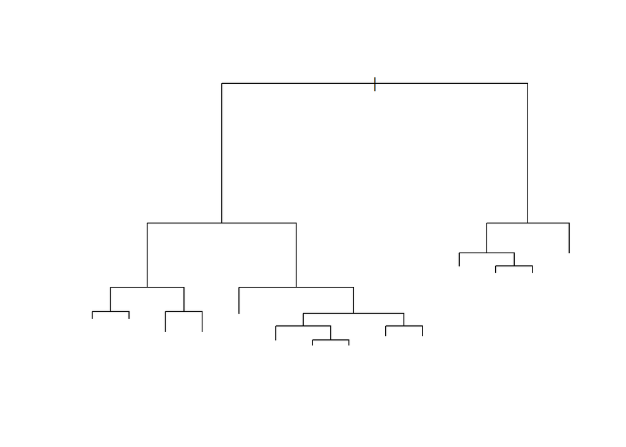

```r
plot(tree.carseats)
```

```r
tree.pred = predict(tree.carseats, Carseats[-train,])
err.dt = mean((Carseats[-train,]$Sales - tree.pred)^2)
err.dt
```

```
## [1] 4.722604
```

test mse is about = 4.722

**(c)**

```r
tree.cs = cv.tree(tree.carseats)
tree.cs
```

```
## $size
##  [1] 14 13 12 11 10  9  7  6  5  4  3  2  1
##
## $dev
##  [1] 1064.8423 1027.5458  987.7539  962.2125 1021.9406 1050.5952 1050.5952
##  [8] 1140.8750 1275.4370 1267.5077 1305.3420 1586.7189 2131.9843
##
## $k
##  [1]      -Inf  21.77205  25.48400  27.69504  40.47126  54.34827  54.72277
##  [8]  82.67454 100.51190 107.20747 122.79088 264.83742 575.02589
##
## $method
## [1] "deviance"
##
## attr(,"class")
## [1] "prune"         "tree.sequence"
```

plotting the error:

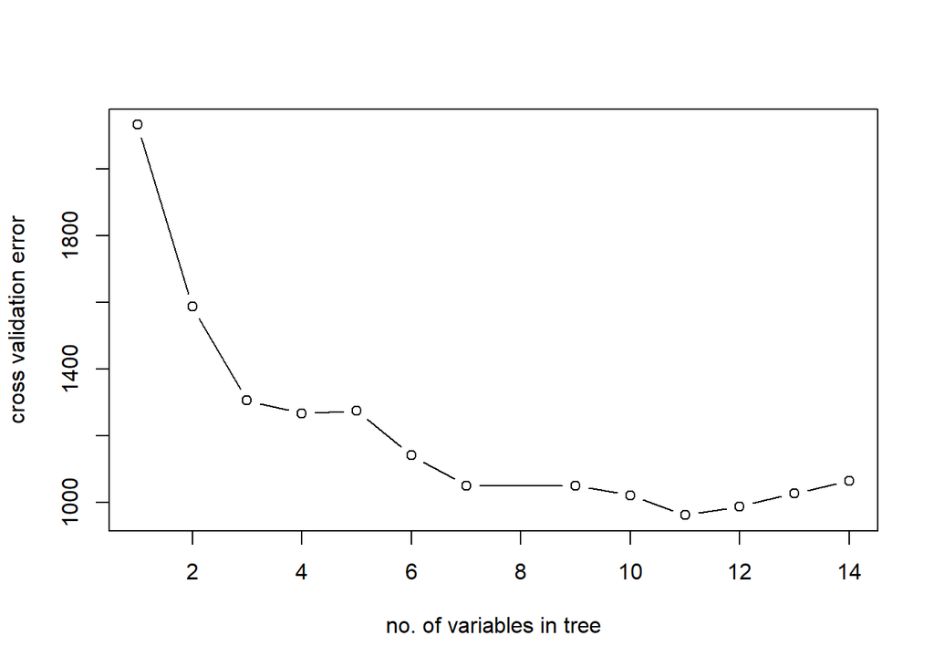

```r
plot(tree.cs$size, tree.cs$dev, type="b", ylab="cross validation error", xlab="no. of variables in tree")
```

tree of size 11 is giving least cross validation error.

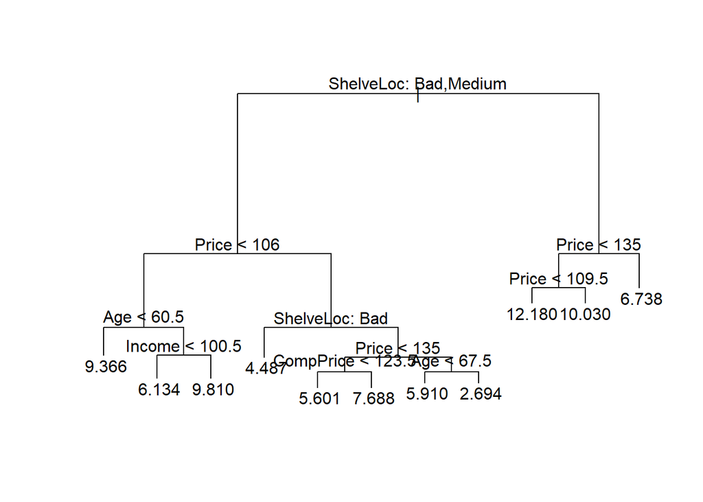

```r
pruned.carseats = prune.tree(tree.carseats, best = 11)
plot(pruned.carseats)
text(pruned.carseats, pretty = 0)
```

```r
pred.pruned = predict(pruned.carseats, newdata = Carseats[-train,])
err.cv = mean((Carseats[-train,]$Sales - pred.pruned)^2)
err.cv
```

```
## [1] 4.992024
```

```r
err.dt
```

```
## [1] 4.722604
```

pruning the tree has increases the test MSE to 4.99

**(d)** we can do bagging `randomForest()` by using `mtry` as all variables.

```r
library(randomForest)
bag.carseats = randomForest(Sales~. , data= Carseats, subset= train, importance = TRUE, mtry = dim(Carseats)[2]-1)
bag.carseats
```

```
##
## Call:
##  randomForest(formula = Sales ~ ., data = Carseats, importance = TRUE,      mtry = dim(Carseats)[2] - 1, subset = train)
##                Type of random forest: regression
##                      Number of trees: 500
## No. of variables tried at each split: 10
##
##           Mean of squared residuals: 2.595603
##                     % Var explained: 69.07
```

```r
pred.bag = predict(bag.carseats, newdata = Carseats[-train,])
err.bag = mean((Carseats[-train,]$Sales - pred.bag)^2)
err.bag
```

```
## [1] 2.513317
```

```r
err.cv
```

```
## [1] 4.992024
```

```r
err.dt
```

```
## [1] 4.722604
```

```r
importance(bag.carseats)
```

```
##                %IncMSE IncNodePurity
## CompPrice   23.4416065    179.256459
## Income       7.1789392     98.218989
## Advertising 13.8827153     90.950842
## Population  -3.6743738     70.975993
## Price       64.0262685    649.636397
## ShelveLoc   70.3503749    689.944020
## Age         21.8604830    185.855454
## Education    3.3489977     59.910563
## Urban       -0.1291602      6.309611
## US           3.2389305     13.714147
```

price, shelveloc, age, compPrice are variables which are most important.

**(e)**

```r
rf.carseats = randomForest(Sales~.-Sales , data= Carseats, subset= train, importance = TRUE )
rf.carseats
```

```
##
## Call:
##  randomForest(formula = Sales ~ . - Sales, data = Carseats, importance = TRUE,      subset = train)
##                Type of random forest: regression
##                      Number of trees: 500
## No. of variables tried at each split: 3
##
##           Mean of squared residuals: 3.023156
##                     % Var explained: 63.98
```

```r
pred.rf = predict(rf.carseats, newdata = Carseats[-train,])
err.rf = mean((Carseats[-train,]$Sales - pred.rf)^2)
err.rf
```

```
## [1] 2.705921
```

determing importance of variables:

```r
rf.carseats$importance
```

```
##                  %IncMSE IncNodePurity
## CompPrice    0.400652731     163.38729
## Income       0.077021596     145.41386
## Advertising  0.472514125     146.04829
## Population  -0.056166154     131.97032
## Price        3.551141425     529.54681
## ShelveLoc    4.122600264     529.04064
## Age          0.713823822     213.33303
## Education    0.033031070      83.19175
## Urban       -0.006322727      17.58371
## US           0.090240326      24.92488
```

Price, Shelveloc, Age are three most important variables.

Now, we will determine effect of `mtry` on test error rate: total variables excluding sales = `rdim(Carseats)[2]-1`

```r
err = rep(NA,10)
for(k in 1:10){
  rf.carseats = randomForest(Sales~.-Sales , data= Carseats, subset= train, mtry= k )
  pred = predict(rf.carseats, newdata = Carseats[-train,])
  err[k] = mean((Carseats[-train,]$Sales - pred)^2)
}
err
```

```
##  [1] 4.177422 3.088403 2.695129 2.568375 2.531122 2.450870 2.477681
##  [8] 2.468148 2.411987 2.487574
```

we can also plot the errors:

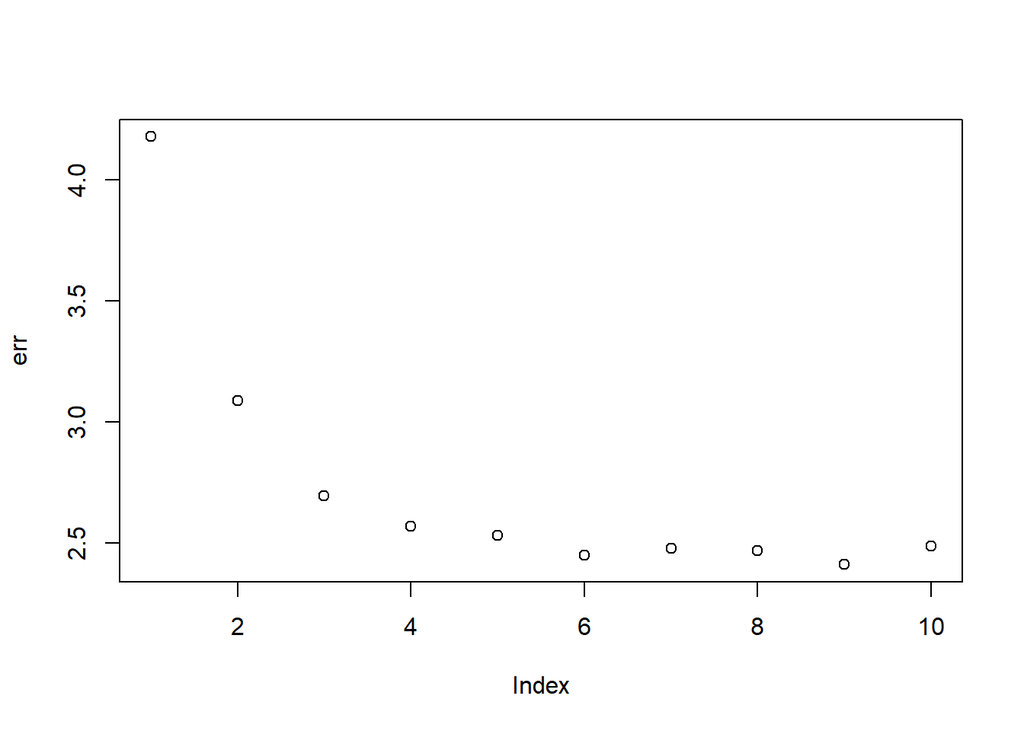

```r
plot(err)
```

We can see that afterwards model with `mtry = 5`, the error rate is not much changing.

we will also plot the errors obtained from different models.

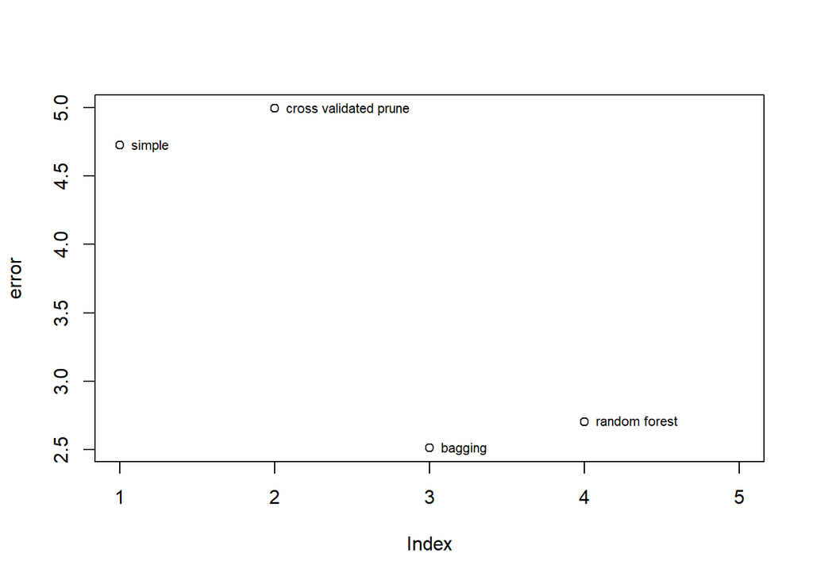

```r
error = c(err.dt,err.cv, err.bag, err.rf)
plot(error, xlim = c(1,5))
text(error,label=c("simple","cross validated prune","bagging", "random forest"), cex= 0.7, pos=4)
```

bagging gives best results.

**Question No.-9**

```r
library(ISLR)
library(MASS)
library(tree)
library(randomForest)
attach(OJ)
set.seed(1001)
dim(OJ)
```

```
## [1] 1070   18
```

**(a)** creating a train variable containing 800 random indexes

```r
train = sample(1:dim(OJ)[1], 800)
```

**(b)**

```r
tree.oj = tree(Purchase~. , data= OJ, subset= train)
summary(tree.oj)
```

```
##
## Classification tree:
## tree(formula = Purchase ~ ., data = OJ, subset = train)
## Variables actually used in tree construction:
## [1] "LoyalCH"   "PriceDiff"
## Number of terminal nodes:  8
## Residual mean deviance:  0.7294 = 577.7 / 792
## Misclassification error rate: 0.16 = 128 / 800
```

Tree only used two variables. training error rate = 0.16 terminal nodes = 8

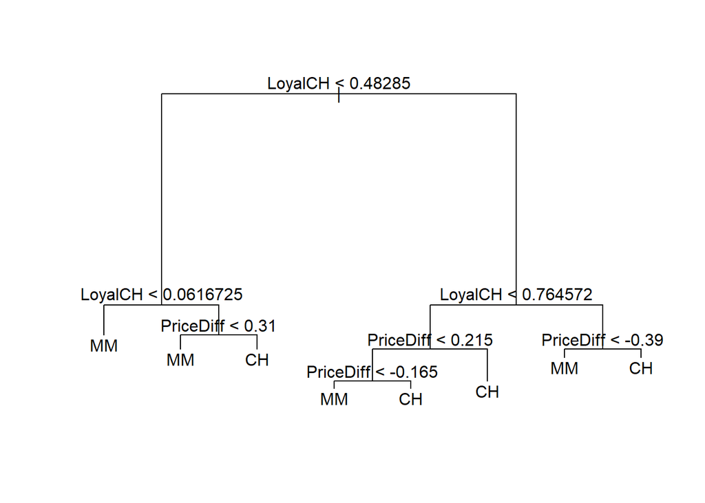

```r
plot(tree.oj)
text(tree.oj, pretty=0)
```

**(c)**

```r
tree.oj
```

```
## node), split, n, deviance, yval, (yprob)
##       * denotes terminal node
##
##  1) root 800 1070.000 CH ( 0.61000 0.39000 )
##    2) LoyalCH < 0.48285 299  323.000 MM ( 0.23077 0.76923 )
##      4) LoyalCH < 0.0616725 69    0.000 MM ( 0.00000 1.00000 ) *
##      5) LoyalCH > 0.0616725 230  281.000 MM ( 0.30000 0.70000 )
##       10) PriceDiff < 0.31 181  193.700 MM ( 0.22652 0.77348 ) *
##       11) PriceDiff > 0.31 49   66.920 CH ( 0.57143 0.42857 ) *
##    3) LoyalCH > 0.48285 501  446.600 CH ( 0.83633 0.16367 )
##      6) LoyalCH < 0.764572 235  286.300 CH ( 0.70213 0.29787 )
##       12) PriceDiff < 0.215 111  153.900 MM ( 0.49550 0.50450 )
##         24) PriceDiff < -0.165 34   39.300 MM ( 0.26471 0.73529 ) *
##         25) PriceDiff > -0.165 77  103.800 CH ( 0.59740 0.40260 ) *
##       13) PriceDiff > 0.215 124   87.430 CH ( 0.88710 0.11290 ) *
##      7) LoyalCH > 0.764572 266   97.820 CH ( 0.95489 0.04511 )
##       14) PriceDiff < -0.39 6    8.318 MM ( 0.50000 0.50000 ) *
##       15) PriceDiff > -0.39 260   78.230 CH ( 0.96538 0.03462 ) *
```

let’s pick variable 11. 11) PriceDiff > 0.31 49 66.920 CH ( 0.57143 0.42857 ) *

1. Splitting variable at this node is `PriceDiff`. The splitting value is 0.31.
2. There are 49 data points in subtree below this node.
3. The deviance of all points contained in region below this node is 66.920
4. - indicates it is a terminal node.
5. prediction at this node is sales = CH
6. about 57% of points in this node CH values of sales.

**(d)**

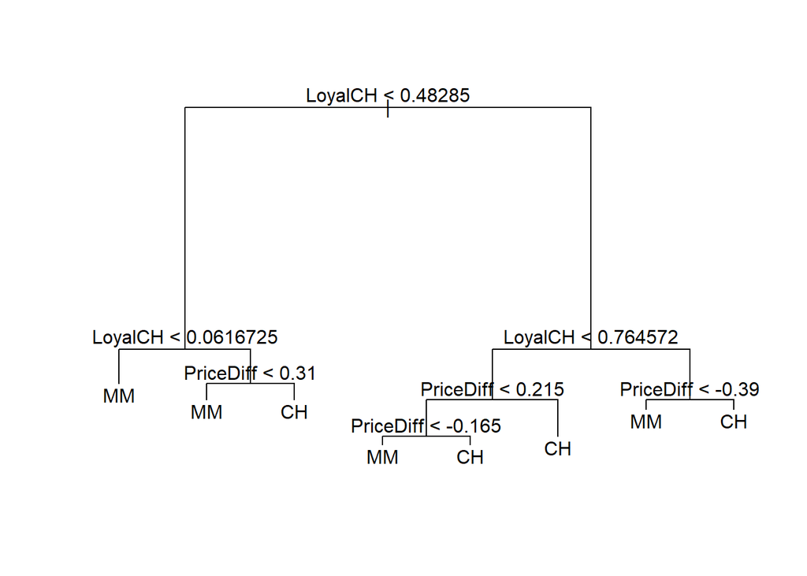

```r
plot(tree.oj)
text(tree.oj, pretty=0)
```

`LoyalCh` is the most important variable. as top 3 nodes contain `LoyalCh`.

**(e)**

```r
pred.tree = predict(tree.oj, newdata = OJ[-train,], type="class")
table(OJ[-train,"Purchase"],pred.tree)
```

```
##     pred.tree
##       CH  MM
##   CH 142  23
##   MM  31  74
```

```r
err.test = (23+31)/length(pred.tree)
err.test
```

```
## [1] 0.2
```

**(f)**

```r
ojtree.cv = cv.tree(tree.oj, FUN= prune.misclass)
ojtree.cv
```

```
## $size
## [1] 8 7 5 2 1
##
## $dev
## [1] 159 159 160 161 312
##
## $k
## [1]       -Inf   0.000000   3.500000   5.333333 161.000000
##
## $method
## [1] "misclass"
##
## attr(,"class")
## [1] "prune"         "tree.sequence"
```

Tree with 7 terminal nodes gives lowest cross-validation error rate.

**(g)**

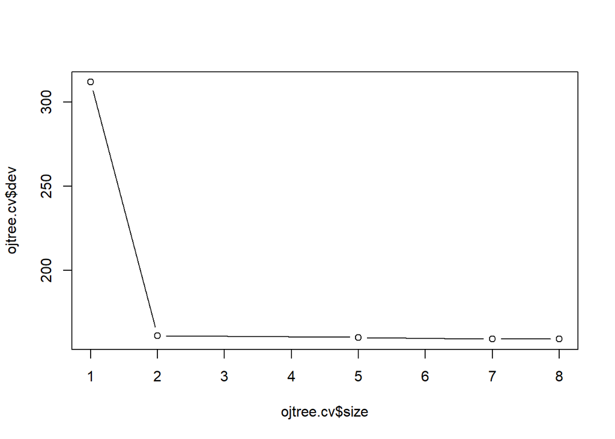

```r
plot(ojtree.cv$size, ojtree.cv$dev, type="b")
```

**(h)** tree size = 7 corresponds to lowest cross-validated classification error rate.

**(i)**

```r
tree.pruned = prune.tree(tree.oj, best=7)
summary(tree.pruned)
```

```
##
## Classification tree:
## snip.tree(tree = tree.oj, nodes = 12L)
## Variables actually used in tree construction:
## [1] "LoyalCH"   "PriceDiff"
## Number of terminal nodes:  7
## Residual mean deviance:  0.7421 = 588.5 / 793
## Misclassification error rate: 0.1788 = 143 / 800
```

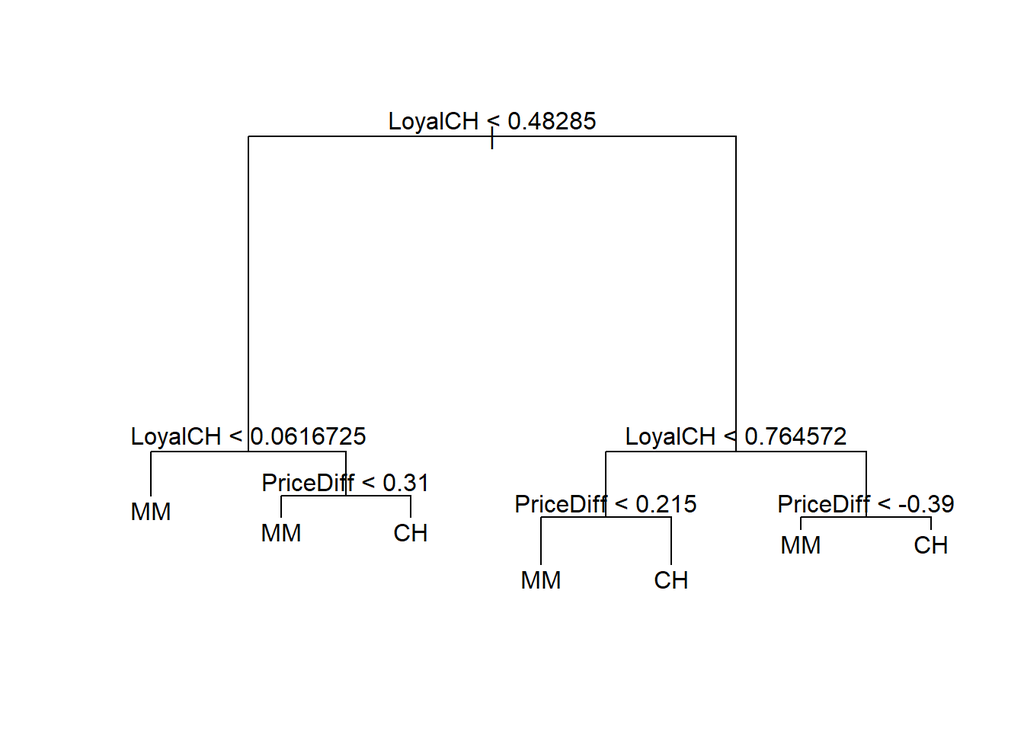

```r
plot(tree.pruned)
text(tree.pruned, pretty=0)
```

**(j)**

```r
errtrain.tree = summary(tree.oj)$mis[1]/summary(tree.oj)$mis[2]

errtrain.pruned = summary(tree.pruned)$mis[1]/summary(tree.pruned)$mis[2]
errtrain.tree
```

```
## [1] 0.16
```

```r
errtrain.pruned
```

```
## [1] 0.17875
```

Pruned tree has higher training error.

**(k)**

```r
pred.tree = predict(tree.oj, newdata = OJ[-train,], type= "class")
errtest.tree = sum(OJ[-train,]$Purchase != pred.tree)/length(pred.tree)

pred.pruned = predict(tree.pruned, newdata = OJ[-train,], type= "class")
errtest.pruned  = sum(OJ[-train,]$Purchase != pred.pruned)/length(pred.pruned)

errtest.tree
```

[output not shown]

```r
errtest.pruned
```

```
## [1] 0.2777778
```

Unpruned tree has low test error than pruned tree.